# Homework12

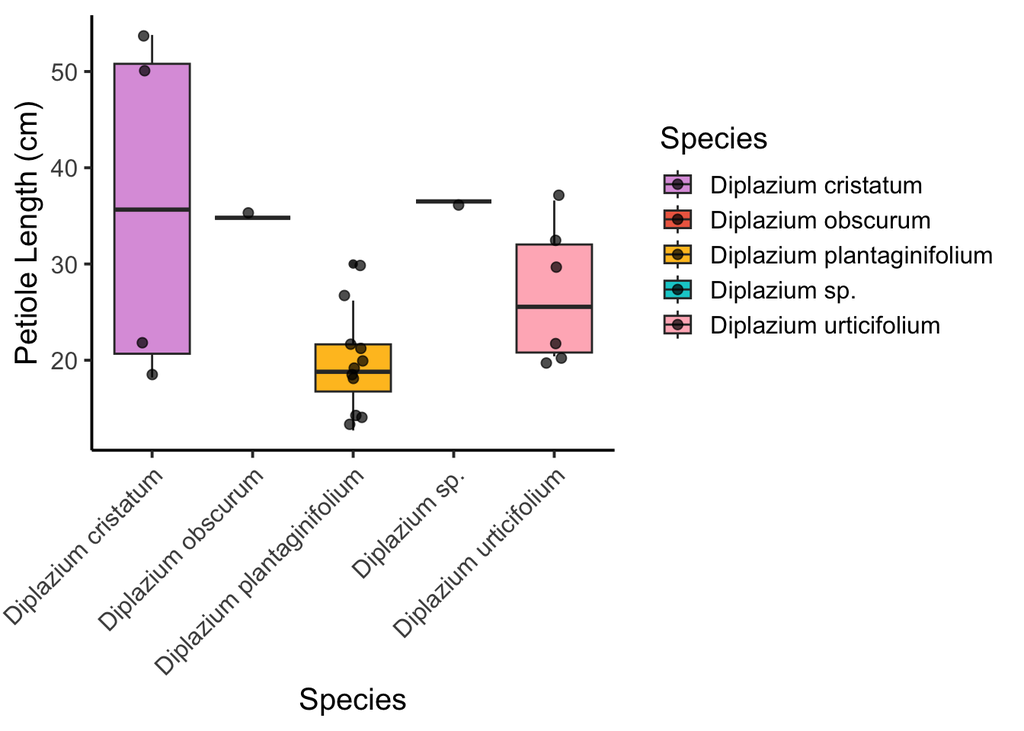

```r
p2
```

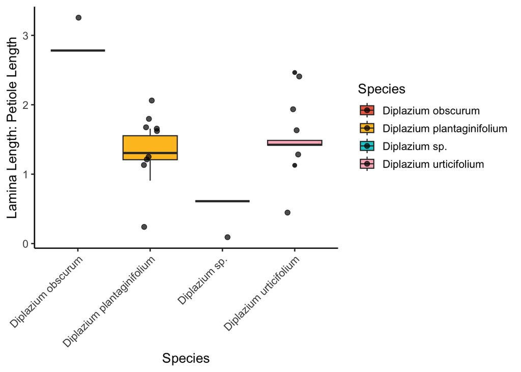

```r
p3
```

To measure leaf width I played around with 2 different ways to measure width (one was perpendicular and the other was along the branching veins). Let’s see how different those graphs look from each other.

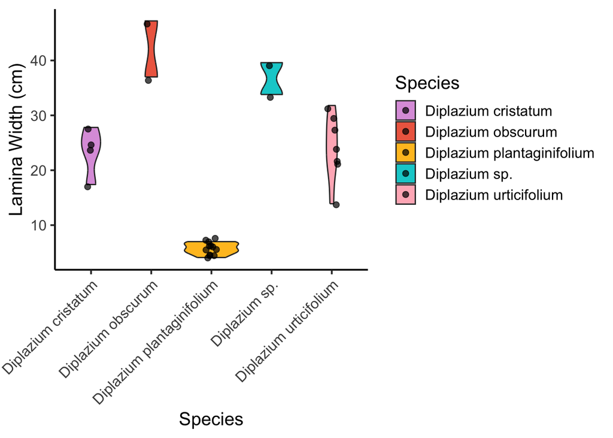

```r
# Measuring width along the leaf veins
p4 <- ggplot(data = subset(sdata, !is.na(LeafWidthAlong.cm.))) +
  aes(x=Species, y=LeafWidthAlong.cm., fill=Species) +
  geom_violin() +
  ylab("Lamina Width (cm)") +
  theme_classic(base_size = 15) +
  scale_fill_manual(values=c("plum","coral2","goldenrod1","darkturquoise","lightpink")) +
  geom_point(position=position_jitter(width=0.1, height=0.7),
                                      color="black", alpha= 0.7, size=2) +
  theme(axis.text.x = element_text(angle = 45, vjust = 1, hjust=1))

# Measuring width perpendicular to the rachis
p5 <- ggplot(data = subset(sdata, !is.na(LeafWidthPerpendicular.cm.))) +
  aes(x=Species, y=LeafWidthPerpendicular.cm., fill=Species) +
  geom_violin() +
  ylab("Lamina Width (cm)") +
  theme_classic(base_size = 15) +
  scale_fill_manual(values=c("plum","coral2","goldenrod1","darkturquoise","lightpink")) +
  geom_point(position=position_jitter(width=0.1, height=0.7),
                                      color="black", alpha= 0.7, size=2) +
  theme(axis.text.x = element_text(angle = 45, vjust = 1, hjust=1))

p4
```

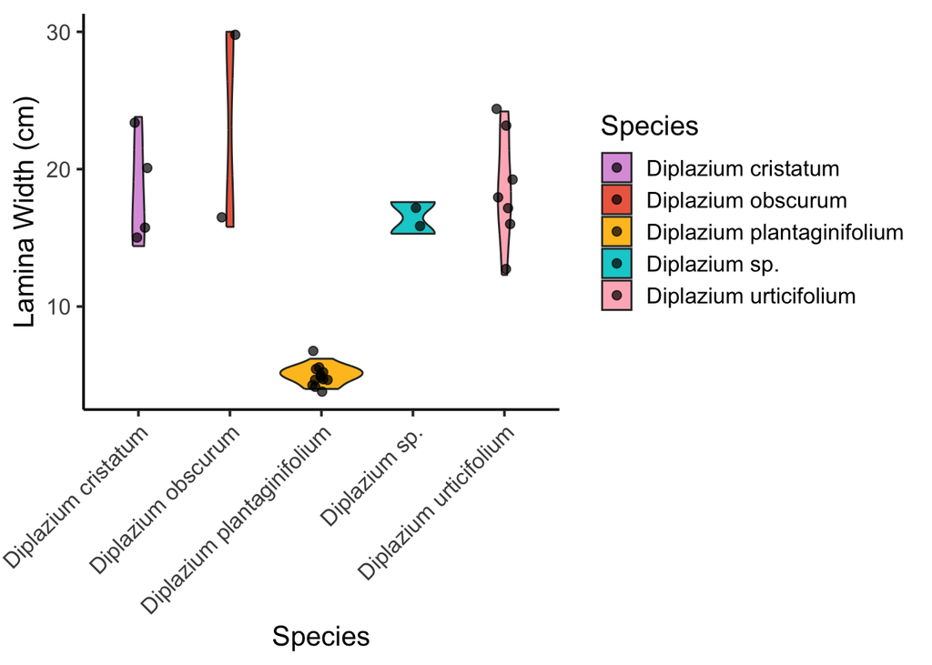

```r
p5
```

Measuring leaf width along the leaf veins definitely seems to separate out the species a little more than perpendicular width. Next, let’s see how this might affect the length to width ratio.

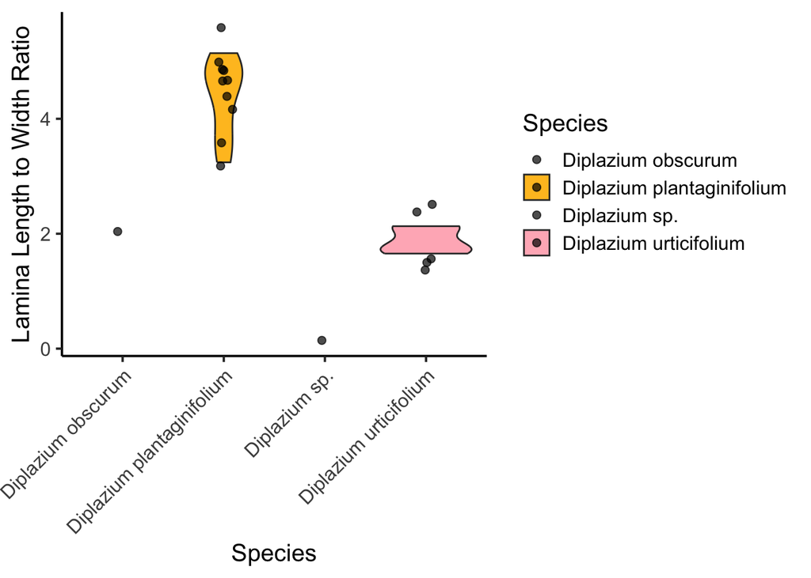

```r
# Measuring width along the leaf veins
p6 <- ggplot(data = subset(sdata, !is.na(LL_WA))) +
  aes(x=Species, y=LL_WA, fill=Species) +
  geom_violin() +
  ylab("Lamina Length to Width Ratio") +
  theme_classic(base_size = 15) +
  scale_fill_manual(values=c("coral2","goldenrod1","darkturquoise","lightpink")) +
  geom_point(position=position_jitter(width=0.1, height=0.7),
                                      color="black", alpha= 0.7, size=2) +
  theme(axis.text.x = element_text(angle = 45, vjust = 1, hjust=1))

# Measuring width perpendicular to the rachis
p7 <- ggplot(data = subset(sdata, !is.na(LL_WP))) +
  aes(x=Species, y=LL_WP, fill=Species) +
  geom_violin() +
  ylab("Lamina Length to Width Ratio") +
  theme_classic(base_size = 15) +
  scale_fill_manual(values=c("coral2","goldenrod1","darkturquoise","lightpink")) +
  geom_point(position=position_jitter(width=0.1, height=0.7),
                                      color="black", alpha= 0.7, size=2) +
  theme(axis.text.x = element_text(angle = 45, vjust = 1, hjust=1))

p6
```

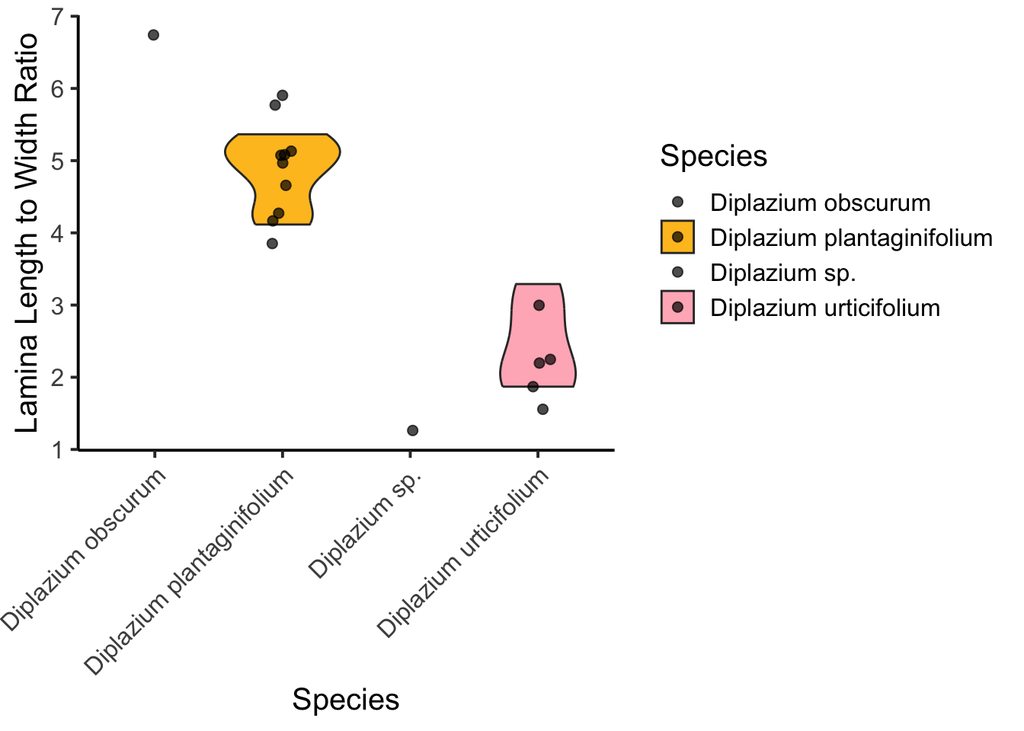

```r
p7
```

Different measuring techniques drastically changes the L:W ratio for D. obscurum. However, based on both plots, Diplazium sp. has a much lower L:W ratio than any of the parent candidates I’ve gotten measurements for so far.

A lot of these plots did not look good as facet plots because there were too many groups. For the following facet plots, I am going to try and focus on just Diplazium sp., D. plantaginifolium, and D. urticifolium.

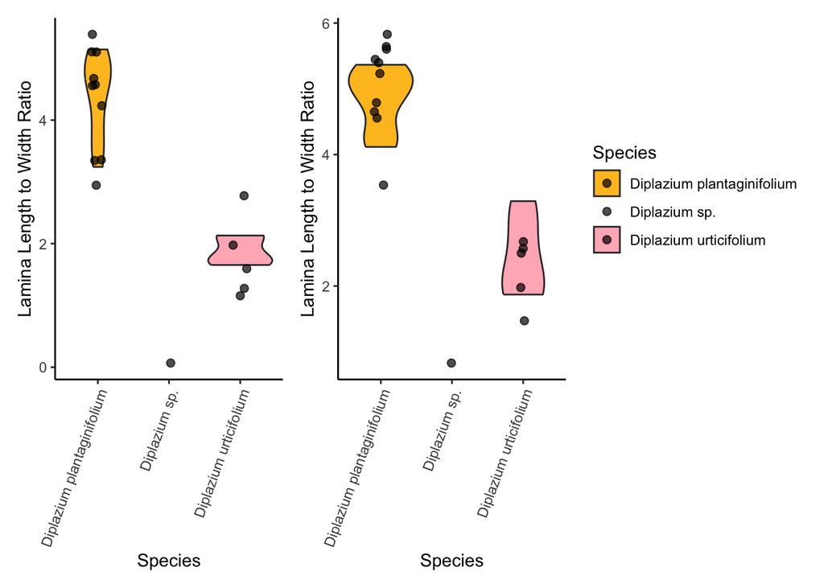

```r
cdata <- sdata[which(sdata$Species!="Diplazium cristatum" &sdata$Species!="Diplazium obscurum"),]

# Same data as p6
p8 <- ggplot(data = subset(cdata, !is.na(LL_WA))) +
  aes(x=Species, y=LL_WA, fill=Species) +
  geom_violin(show.legend = F) +
  ylab("Lamina Length to Width Ratio") +
  theme_classic() +
  scale_fill_manual(values=c("goldenrod1","darkturquoise","lightpink")) +
  geom_point(position=position_jitter(width=0.1, height=0.7),
                                      color="black", alpha= 0.7, size=2,show.legend = F) +
  theme(axis.text.x = element_text(angle = 70, vjust = 1, hjust=1))

# Same data as p7
p9 <- ggplot(data = subset(cdata, !is.na(LL_WP))) +
  aes(x=Species, y=LL_WP, fill=Species) +
  geom_violin() +
  ylab("Lamina Length to Width Ratio") +
  theme_classic() +
  scale_fill_manual(values=c("goldenrod1","darkturquoise","lightpink")) +
  geom_point(position=position_jitter(width=0.1, height=0.7),
                                      color="black", alpha= 0.7, size=2) +
  theme(axis.text.x = element_text(angle = 70, vjust = 1, hjust=1))

p8 + p9
```